# Practical Machine Learning Assignment

Alana Souter

28 November 2017

## Background

Using devices such as Jawbone Up, Nike FuelBand, and Fitbit it is now possible to collect a large amount of data about personal activity relatively inexpensively. These type of devices are part of the quantified self movement - a group of enthusiasts who take measurements about themselves regularly to improve their health, to find patterns in their behavior, or because they are tech geeks. One thing that people regularly do is quantify how much of a particular activity they do, but they rarely quantify how well they do it. In this project, your goal will be to use data from accelerometers on the belt, forearm, arm, and dumbell of 6 participants. They were asked to perform barbell lifts correctly and incorrectly in 5 different ways. More information is available from the website here: http://web.archive.org/web/20161224072740/http:/groupware.les.inf.puc-rio.br/har (see the section on the Weight Lifting Exercise Dataset).

## Overview

The goal of this project is to predict the manner in which the 6 participants did the exercise. This is the “classe” variable in the training set. This report describes how the model was built, how cross validation was used and what the expected out of sample error is.

## The Data

The training data for this project are available here: https://d396qusza40orc.cloudfront.net/predmachlearn/pml-training.csv

The test data are available here: https://d396qusza40orc.cloudfront.net/predmachlearn/pml-testing.csv

The data for this project come from this source: http://groupware.les.inf.puc-rio.br/har

Special thanks go to the authors for allowing the data to be used for this assignment.

**Preparing the Environment**

```r
library(knitr)
library(rpart)
library(rpart.plot)
library(randomForest)
library(caret)
set.seed(12345)
opts_chunk$set(echo=TRUE,results='hold')
```

**Loading the Data**

```r
setwd("D:/Users/soutal/datasciencecoursera")
training <- read.csv("pml-training.csv", na.strings=c("NA","#DIV/0!",""))
testing <- read.csv("pml-testing.csv", na.strings=c("NA","#DIV/0!",""))
```

**Initial Exploratory Analysis & Cleanup**

```r
dim(training)
dim(testing)
```

```
## [1] 19622   160
## [1]  20 160
```

```r
str(training,list.len=20)
str(testing,list.len=20)
```

```
## 'data.frame':    19622 obs. of  160 variables:
##  $ X                       : int  1 2 3 4 5 6 7 8 9 10 ...
##  $ user_name               : Factor w/ 6 levels "adelmo","carlitos",..: 2 2 2 2 2 2 2 2 2 2 ...
##  $ raw_timestamp_part_1    : int  1323084231 1323084231 1323084231 1323084232 1323084232 1323084232 1323084232 1323084232 1323084232 1323084232 ...
##  $ raw_timestamp_part_2    : int  788290 808298 820366 120339 196328 304277 368296 440390 484323 484434 ...
##  $ cvtd_timestamp          : Factor w/ 20 levels "02/12/2011 13:32",..: 9 9 9 9 9 9 9 9 9 9 ...
##  $ new_window              : Factor w/ 2 levels "no","yes": 1 1 1 1 1 1 1 1 1 1 ...
##  $ num_window              : int  11 11 11 12 12 12 12 12 12 12 ...
##  $ roll_belt               : num  1.41 1.41 1.42 1.48 1.48 1.45 1.42 1.42 1.43 1.45 ...
##  $ pitch_belt              : num  8.07 8.07 8.07 8.05 8.07 8.06 8.09 8.13 8.16 8.17 ...
##  $ yaw_belt                : num  -94.4 -94.4 -94.4 -94.4 -94.4 -94.4 -94.4 -94.4 -94.4 -94.4 ...
##  $ total_accel_belt        : int  3 3 3 3 3 3 3 3 3 3 ...
##  $ kurtosis_roll_belt      : num  NA NA NA NA NA NA NA NA NA NA ...
##  $ kurtosis_picth_belt     : num  NA NA NA NA NA NA NA NA NA NA ...
##  $ kurtosis_yaw_belt       : logi  NA NA NA NA NA NA ...
```

[output cut: 29 more lines]

1. Remove variables with too many NA values

```r
allNA<-sapply(training,function(x) mean(is.na(x)))
training<-training[,allNA==FALSE]
dim(training)
allNA<-sapply(testing,function(x) mean(is.na(x)))
testing<-testing[,allNA==FALSE]
dim(testing)
```

```
## [1] 19622    60
## [1] 20 60
```

2. Check for numeric variables which have no or zero variance to see if we can reduce the variables this way

```r
nearZeroVar(training[, sapply(training,is.numeric)])
nearZeroVar(testing[, sapply(testing,is.numeric)])
```

```
## integer(0)
## integer(0)
```

3. Remove idenfication only variables

```r
training<-training[,-(1:5)]
testing<-testing[,-(1:5)]
```

4. Split data for cross validation into a training and testing set. A 60/40 split has been chosen for training/testing.

```r
inTrain<-createDataPartition(y=training$classe, p=0.60, list=FALSE)
train1<-training[inTrain,]
test1<-training[-inTrain,]
dim(train1)
dim(test1)
```

```
## [1] 11776    55
## [1] 7846   55
```

## Models for Prediction

**Random Forest**

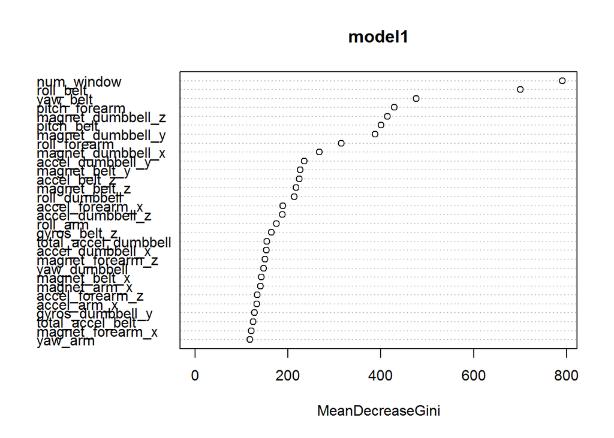

```r
model1<-randomForest(classe~.,data=train1,ntree=1000)
varImpPlot(model1)
```

We will now check this models accuracy

```r
predictions<-predict(model1,newdata=test1)
confusionMat<-confusionMatrix(predictions,test1$classe)
confusionMat
```

```
## Confusion Matrix and Statistics
##
##           Reference
## Prediction    A    B    C    D    E
##          A 2232    3    0    0    0
##          B    0 1513    3    0    0
##          C    0    2 1365   15    0
##          D    0    0    0 1270    3
##          E    0    0    0    1 1439
##
## Overall Statistics
##
##                Accuracy : 0.9966
##                  95% CI : (0.995, 0.9977)
##     No Information Rate : 0.2845
##     P-Value [Acc > NIR] : < 2.2e-16
##
##                   Kappa : 0.9956
##  Mcnemar's Test P-Value : NA
##
## Statistics by Class:
##
##                      Class: A Class: B Class: C Class: D Class: E
## Sensitivity            1.0000   0.9967   0.9978   0.9876   0.9979
## Specificity            0.9995   0.9995   0.9974   0.9995   0.9998
## Pos Pred Value         0.9987   0.9980   0.9877   0.9976   0.9993
## Neg Pred Value         1.0000   0.9992   0.9995   0.9976   0.9995
## Prevalence             0.2845   0.1935   0.1744   0.1639   0.1838
## Detection Rate         0.2845   0.1928   0.1740   0.1619   0.1834
## Detection Prevalence   0.2849   0.1932   0.1761   0.1622   0.1835
## Balanced Accuracy      0.9997   0.9981   0.9976   0.9936   0.9989
```

This model has a 99.6% accuracy on the test dataset! On this basis I will not test any other models (such as Decision Tree) as I’m happy this model is a good option for applying to the predictions.

**Out of sample error rate** The above Random Forest out of sample error rate is calculated by:

```r
missClass = function(values, predicted) {
  sum(predicted != values) / length(values)
}
OOS_errRate = missClass(test1$classe, predictions)
OOS_errRate
```

```
## [1] 0.003441244
```

The out of sample error rate is 0.34%

## Prediction

We will now use the Random Forest model on the validation(testing) data.  
From attempting to run this using “prediction<-predict(model1,newdata=testing)” I discovered there was an inconsistency between the training & testing data which created an error message when running randomForest. In order to find the issue and correct it I carried out the following:

```r
sapply(train1, class)
sapply(testing, class)
```

```
##           new_window           num_window            roll_belt
##             "factor"            "integer"            "numeric"
##           pitch_belt             yaw_belt     total_accel_belt
##            "numeric"            "numeric"            "integer"
##         gyros_belt_x         gyros_belt_y         gyros_belt_z
##            "numeric"            "numeric"            "numeric"
##         accel_belt_x         accel_belt_y         accel_belt_z
##            "integer"            "integer"            "integer"
##        magnet_belt_x        magnet_belt_y        magnet_belt_z
##            "integer"            "integer"            "integer"
##             roll_arm            pitch_arm              yaw_arm
##            "numeric"            "numeric"            "numeric"
##      total_accel_arm          gyros_arm_x          gyros_arm_y
##            "integer"            "numeric"            "numeric"
##          gyros_arm_z          accel_arm_x          accel_arm_y
##            "numeric"            "integer"            "integer"
##          accel_arm_z         magnet_arm_x         magnet_arm_y
##            "integer"            "integer"            "integer"
##         magnet_arm_z        roll_dumbbell       pitch_dumbbell
##            "integer"            "numeric"            "numeric"
##         yaw_dumbbell total_accel_dumbbell     gyros_dumbbell_x
##            "numeric"            "integer"            "numeric"
##     gyros_dumbbell_y     gyros_dumbbell_z     accel_dumbbell_x
##            "numeric"            "numeric"            "integer"
##     accel_dumbbell_y     accel_dumbbell_z    magnet_dumbbell_x
##            "integer"            "integer"            "integer"
##    magnet_dumbbell_y    magnet_dumbbell_z         roll_forearm
##            "integer"            "numeric"            "numeric"
##        pitch_forearm          yaw_forearm  total_accel_forearm
##            "numeric"            "numeric"            "integer"
##      gyros_forearm_x      gyros_forearm_y      gyros_forearm_z
##            "numeric"            "numeric"            "numeric"
##      accel_forearm_x      accel_forearm_y      accel_forearm_z
##            "integer"            "integer"            "integer"
##     magnet_forearm_x     magnet_forearm_y     magnet_forearm_z
##            "integer"            "numeric"            "numeric"
##               classe
##             "factor"
##           new_window           num_window            roll_belt
##             "factor"            "integer"            "numeric"
```

[output cut: 21 more lines]

```
##            "numeric"            "numeric"            "integer"
##     accel_dumbbell_y     accel_dumbbell_z    magnet_dumbbell_x
##            "integer"            "integer"            "integer"
##    magnet_dumbbell_y    magnet_dumbbell_z         roll_forearm
##            "integer"            "integer"            "numeric"
##        pitch_forearm          yaw_forearm  total_accel_forearm
##            "numeric"            "numeric"            "integer"
##      gyros_forearm_x      gyros_forearm_y      gyros_forearm_z
##            "numeric"            "numeric"            "numeric"
##      accel_forearm_x      accel_forearm_y      accel_forearm_z
##            "integer"            "integer"            "integer"
##     magnet_forearm_x     magnet_forearm_y     magnet_forearm_z
##            "integer"            "integer"            "integer"
##           problem_id
##            "integer"
```

This highlighted that there were class mismatches in the columns “magnet_dumbbell_z, magnet_forearm_y and magnet_forearm_z, problem_id”. I therefore had to correct this before running the prediction again:

```r
fixFrame<-head(training,1)
fixFrame<-fixFrame[,-length(colnames(fixFrame))]
validation<-testing[,-(55)]
validation<-rbind(fixFrame,validation)
validation<-validation[-1,]
prediction<-predict(model1,newdata=validation)
prediction
```

```
##  2  3  4  5  6  7  8  9 10 11 12 13 14 15 16 17 18 19 20 21
##  B  A  B  A  A  E  D  B  A  A  B  C  B  A  E  E  A  B  B  B
## Levels: A B C D E
```